# Bank Telemarketing Analysis

### Content

A. Introduction  
B. Problem Statement  
C. Our Data  
D. Modeling Process  
E. Final Thoughts

### A. Introduction

Telemarketing is a method of selling products and services over the phone to customers. It has always been a controversial approach. On one hand, it is easy to directly reach out to customers and also cheaper than other marketing methods. On the other hand, it has bad reputations of damaging the company’s image and some of the startup costs are very expensive.  
In this project, we are looking into how other factors can affect the outcome of telemarketing campaigns for a specific institution, Portuguese retail bank, and make prediction based on our model. The main focus of this project is incredibly interesting since we typically feel annoyed by telemarketing.

### B. Problem Statement

Our main question is what is likely to be the outcome of the telemarketing campaigns based on the characteristics of the clients and the calls. Our goal is to predict if the client will subscribe (yes/no) to a term deposit (variable y).  
Note: A term deposit is a type of deposit account held at a financial institution where money is locked up for some set period of time.

### C. Our Data

#### 1. Data Source

• Dataset name: Bank Tele-Marketing Data Set  
• Original Source of the Dataset: [Moro et al., 2014] S. Moro, P. Cortez and P. Rita. A Data-Driven Approach to Predict the Success of Bank Telemarketing. Decision Support Systems, Elsevier, 62:22-31, June 2014  
• We retrieve the data from UCI Machine Learning Repository. The data is accessible [here](http://archive.ics.uci.edu/ml/datasets/Bank+Marketing).

#### 2. Background

• The data is collected from several telemarketing campaigns in which the Portuguese bank attempted to target customers through phone calls to sell long-term deposits.  
• The dataset includes both the phone calls of which the bank executed and the phone calls of which clients contacted the help center.  
• Each observation includes the outcome, whether or not the target customers subscribed the term deposit, and the characteristics of the customers and the phone calls themselves.

#### 3. Variable Description

This dataset was collected from May 2008 to November 2010 with 41188 observations and 20 variables.

| No. | Variable Name | Variable Definiton | Data Type | Units/Categories | Missing Value Codes | Note |
| --- | --- | --- | --- | --- | --- | --- |
| 1 | age | Client’s age | Discrete | years | unknown |  |
| 2 | job | Type of client’s job | Categorical | admin, blue-collar, entrepreneur, housemaid, management, retired, self-employed, services, student, technician, unemployed | unknown |  |
| 3 | marital | Marital status | Categorical | divorced, married, single | unknown | ‘divorced’ means divorced or widowed |
| 4 | education | Education level | Categorical | basic.4y, basic.6y, basic.9y, high.school, illiterate, professional.course, university.degree | unknown |  |
| 5 | default | Has credit in default? | Categorical | yes, no | unknown |  |
| 6 | housing | Has housing loan? | Categorical | yes, no | unknown |  |
| 7 | loan | Has personal loan? | Categorical | yes, no | unknown |  |
| 8 | contact | Contact communication type | Categorical | cellular, telephone | unknown |  |
| 9 | month | Last contact month of year | Categorical | jan, feb, mar, …, nov, dec | unknown |  |
| 10 | day_of_week | Last contact day of the week | Categorical | mon, tue, wed, thu, fri | unknown |  |
| 11 | duration | Last contact duration | Discrete | seconds | unknown | This attribute highly affects the output target (e.g., if duration=0 then y=‘no’). Yet, the duration is not known before a call is performed. |
| 12 | campaign | Number of contacts performed during this campaign and for this client | Discrete | contacts | unknown | including last contact |
| 13 | pdays | Number of days that passed by after the client was last contacted from a previous campaign | Discrete | days | unknown | 999 means client was not previously contacted |
| 14 | previous | Number of contacts performed before this campaign and for this client | Discrete | contacts | unknown |  |
| 15 | poutcome | Outcome of the previous marketing campaign | Categorical | failure, success, nonexistent | unknown |  |
| 16 | emp.var.rate | Employment variation rate - quarterly indicator | Continuous | - | unknown | Calculate the variation of employment rate ⇒ higher variation means the employment rate changes a lot (unstable economy) |
| 17 | cons.price.idx | Consumer price index - monthly indicator | Continuous | - | unknown | The average change in prices over time that consumers pay for a basket of goods and services |
| 18 | cons.conf.idx | Consumer confidence index - monthly indicator | Continuous | - | unknown | Defined as the degree of optimism about the state of the economy that consumers are expressing through their activities of saving and spending |
| 19 | euribor3m | Euribor 3 month rate - daily indicator | Continuous | - | unknown | Euribor is an overnight interbank rate comprised of the average interest rates from a panel of large European banks that are used for lending to one another in euros |
| 20 | nr.employed | Number of employees - quarterly indicator | Numeric | - | unknown |  |
| 21 | y | Has the client subscribed to a term deposit? | Categorical | yes, no | unknown |  |

### 4. Problems with Data

1. There are two many categorical variables that aren’t Bernoulli variables, and it would be complicated to interpret with too many of them  
   ⇒ Possible solutions: change some of them (month, day_of_week, contact, etc) to other type of variables or group some of the categories together
2. Some of the data are not in its correct form (Bernoulli not broken into 0 and 1)
3. Some variables are terminologies
4. Some variables have many NAs
5. Some variables have special cases such as marital, duration, pdays

### 5. Working with Data

#### Read and Explore the dataset

```r
bankDf <- read.csv2("bank-additional-full.csv")
summary(bankDf)
```

```
##       age            job              marital           education
##  Min.   :17.00   Length:41188       Length:41188       Length:41188
##  1st Qu.:32.00   Class :character   Class :character   Class :character
##  Median :38.00   Mode  :character   Mode  :character   Mode  :character
##  Mean   :40.02
##  3rd Qu.:47.00
##  Max.   :98.00
##    default            housing              loan             contact
##  Length:41188       Length:41188       Length:41188       Length:41188
##  Class :character   Class :character   Class :character   Class :character
##  Mode  :character   Mode  :character   Mode  :character   Mode  :character
##
##
##
##     month           day_of_week           duration         campaign
##  Length:41188       Length:41188       Min.   :   0.0   Min.   : 1.000
##  Class :character   Class :character   1st Qu.: 102.0   1st Qu.: 1.000
##  Mode  :character   Mode  :character   Median : 180.0   Median : 2.000
##                                        Mean   : 258.3   Mean   : 2.568
##                                        3rd Qu.: 319.0   3rd Qu.: 3.000
##                                        Max.   :4918.0   Max.   :56.000
##      pdays          previous       poutcome         emp.var.rate
##  Min.   :  0.0   Min.   :0.000   Length:41188       Length:41188
##  1st Qu.:999.0   1st Qu.:0.000   Class :character   Class :character
##  Median :999.0   Median :0.000   Mode  :character   Mode  :character
##  Mean   :962.5   Mean   :0.173
##  3rd Qu.:999.0   3rd Qu.:0.000
##  Max.   :999.0   Max.   :7.000
##  cons.price.idx     cons.conf.idx       euribor3m         nr.employed
##  Length:41188       Length:41188       Length:41188       Length:41188
##  Class :character   Class :character   Class :character   Class :character
##  Mode  :character   Mode  :character   Mode  :character   Mode  :character
##
##
##
##       y
##  Length:41188
##  Class :character
##  Mode  :character
##
##
##
```

```r
glimpse(bankDf)
```

```
## Rows: 41,188
## Columns: 21
## $ age            <int> 56, 57, 37, 40, 56, 45, 59, 41, 24, 25, 41, 25, 29, 57,…
## $ job            <chr> "housemaid", "services", "services", "admin.", "service…
## $ marital        <chr> "married", "married", "married", "married", "married", …
## $ education      <chr> "basic.4y", "high.school", "high.school", "basic.6y", "…
## $ default        <chr> "no", "unknown", "no", "no", "no", "unknown", "no", "un…
## $ housing        <chr> "no", "no", "yes", "no", "no", "no", "no", "no", "yes",…
## $ loan           <chr> "no", "no", "no", "no", "yes", "no", "no", "no", "no", …
## $ contact        <chr> "telephone", "telephone", "telephone", "telephone", "te…
## $ month          <chr> "may", "may", "may", "may", "may", "may", "may", "may",…
## $ day_of_week    <chr> "mon", "mon", "mon", "mon", "mon", "mon", "mon", "mon",…
## $ duration       <int> 261, 149, 226, 151, 307, 198, 139, 217, 380, 50, 55, 22…
## $ campaign       <int> 1, 1, 1, 1, 1, 1, 1, 1, 1, 1, 1, 1, 1, 1, 1, 1, 1, 1, 1…
## $ pdays          <int> 999, 999, 999, 999, 999, 999, 999, 999, 999, 999, 999, …
## $ previous       <int> 0, 0, 0, 0, 0, 0, 0, 0, 0, 0, 0, 0, 0, 0, 0, 0, 0, 0, 0…
## $ poutcome       <chr> "nonexistent", "nonexistent", "nonexistent", "nonexiste…
## $ emp.var.rate   <chr> "1.1", "1.1", "1.1", "1.1", "1.1", "1.1", "1.1", "1.1",…
## $ cons.price.idx <chr> "93.994", "93.994", "93.994", "93.994", "93.994", "93.9…
## $ cons.conf.idx  <chr> "-36.4", "-36.4", "-36.4", "-36.4", "-36.4", "-36.4", "…
## $ euribor3m      <chr> "4.857", "4.857", "4.857", "4.857", "4.857", "4.857", "…
## $ nr.employed    <chr> "5191", "5191", "5191", "5191", "5191", "5191", "5191",…
## $ y              <chr> "no", "no", "no", "no", "no", "no", "no", "no", "no", "…
```

#### Data Wrangling

Turn all “unknown” to NA value

```r
bankDf <- bankDf %>% replace_with_na_all(condition = ~.x == "unknown")
```

Turn Bernoulli variables into 0 and 1 categories

```r
bankDf <- rename(bankDf, telephone = contact)
bankDf <- rename(bankDf, deposit = y)

bankDf <- bankDf %>%
  mutate(default = ifelse(default == "yes", 1, 0)) %>%
  mutate(housing = ifelse(housing == "yes", 1, 0)) %>%
  mutate(loan = ifelse(loan == "yes", 1, 0)) %>%
  mutate(telephone = ifelse(telephone == "telephone", 1, 0)) %>%
  mutate(deposit = ifelse(deposit == "yes", 1, 0))
```

Turn other variables into its suitable types of variables

```r
bankDf$job <- as.factor(bankDf$job)
bankDf$marital <- as.factor(bankDf$marital)
bankDf$education <- as.factor(bankDf$education)
bankDf$default <- as.factor(bankDf$default)
bankDf$housing <- as.factor(bankDf$housing)
bankDf$loan <- as.factor(bankDf$loan)
bankDf$telephone <- as.factor(bankDf$telephone)
bankDf$poutcome <- as.factor(bankDf$poutcome)
bankDf$month <- as.factor(bankDf$month)
bankDf$day_of_week <- as.factor(bankDf$day_of_week)

bankDf$previous <- as.numeric(bankDf$previous)
bankDf$emp.var.rate <- as.numeric(bankDf$emp.var.rate)
bankDf$cons.price.idx <- as.numeric(bankDf$cons.price.idx)
bankDf$cons.conf.idx <- as.numeric(bankDf$cons.conf.idx)
bankDf$euribor3m <- as.numeric(bankDf$euribor3m)
bankDf$nr.employed <- as.numeric(bankDf$nr.employed)

bankDf$pdays <- as.factor(bankDf$pdays)
```

#### Data Exploration

```r
summary(bankDf)
```

```
##       age                 job            marital
##  Min.   :17.00   admin.     :10422   divorced: 4612
##  1st Qu.:32.00   blue-collar: 9254   married :24928
##  Median :38.00   technician : 6743   single  :11568
##  Mean   :40.02   services   : 3969   NA's    :   80
##  3rd Qu.:47.00   management : 2924
##  Max.   :98.00   (Other)    : 7546
##                  NA's       :  330
##                education     default      housing        loan       telephone
##  university.degree  :12168   0   :32588   0   :18622   0   :33950   0:26144
##  high.school        : 9515   1   :    3   1   :21576   1   : 6248   1:15044
##  basic.9y           : 6045   NA's: 8597   NA's:  990   NA's:  990
##  professional.course: 5243
##  basic.4y           : 4176
##  (Other)            : 2310
##  NA's               : 1731
##      month       day_of_week    duration         campaign          pdays
##  may    :13769   fri:7827    Min.   :   0.0   Min.   : 1.000   999    :39673
##  jul    : 7174   mon:8514    1st Qu.: 102.0   1st Qu.: 1.000   3      :  439
##  aug    : 6178   thu:8623    Median : 180.0   Median : 2.000   6      :  412
##  jun    : 5318   tue:8090    Mean   : 258.3   Mean   : 2.568   4      :  118
##  nov    : 4101   wed:8134    3rd Qu.: 319.0   3rd Qu.: 3.000   9      :   64
##  apr    : 2632               Max.   :4918.0   Max.   :56.000   2      :   61
##  (Other): 2016                                                 (Other):  421
##     previous            poutcome      emp.var.rate      cons.price.idx
##  Min.   :0.000   failure    : 4252   Min.   :-3.40000   Min.   :92.20
##  1st Qu.:0.000   nonexistent:35563   1st Qu.:-1.80000   1st Qu.:93.08
##  Median :0.000   success    : 1373   Median : 1.10000   Median :93.75
##  Mean   :0.173                       Mean   : 0.08189   Mean   :93.58
##  3rd Qu.:0.000                       3rd Qu.: 1.40000   3rd Qu.:93.99
##  Max.   :7.000                       Max.   : 1.40000   Max.   :94.77
##
##  cons.conf.idx     euribor3m      nr.employed      deposit
##  Min.   :-50.8   Min.   :0.634   Min.   :4964   Min.   :0.0000
##  1st Qu.:-42.7   1st Qu.:1.344   1st Qu.:5099   1st Qu.:0.0000
##  Median :-41.8   Median :4.857   Median :5191   Median :0.0000
##  Mean   :-40.5   Mean   :3.621   Mean   :5167   Mean   :0.1127
##  3rd Qu.:-36.4   3rd Qu.:4.961   3rd Qu.:5228   3rd Qu.:0.0000
##  Max.   :-26.9   Max.   :5.045   Max.   :5228   Max.   :1.0000
##
```

After taking a look at the summary of the dataset, ee decide to remove those columns below:  
- `default` because it has too many NAs  
- `poutcome` (previous campaign’s outcome) because it has too many “nonexistent” result  
- `pdays` (days after the customers were last contacted in the previous campaigns) because most of the customers had never been contacted before

```r
bankDf <- bankDf %>%
  select(!default) %>%
  select(!poutcome) %>%
  select(!pdays)

bankDf <- na.omit(bankDf)
summary(bankDf)
```

```
##       age                 job           marital
##  Min.   :17.00   admin.     :9937   divorced: 4302
##  1st Qu.:32.00   blue-collar:8560   married :23183
##  Median :38.00   technician :6380   single  :10760
##  Mean   :39.86   services   :3716
##  3rd Qu.:47.00   management :2728
##  Max.   :98.00   retired    :1577
##                  (Other)    :5347
##                education     housing   loan      telephone     month
##  basic.4y           : 4002   0:17667   0:32286   0:24441   may    :12794
##  basic.6y           : 2204   1:20578   1: 5959   1:13804   jul    : 6630
##  basic.9y           : 5856                                 aug    : 5822
##  high.school        : 9244                                 jun    : 4846
##  illiterate         :   18                                 nov    : 3898
##  professional.course: 5100                                 apr    : 2436
##  university.degree  :11821                                 (Other): 1819
##  day_of_week    duration         campaign         previous
##  fri:7224    Min.   :   0.0   Min.   : 1.000   Min.   :0.00
##  mon:7927    1st Qu.: 102.0   1st Qu.: 1.000   1st Qu.:0.00
##  thu:8011    Median : 180.0   Median : 2.000   Median :0.00
##  tue:7481    Mean   : 258.2   Mean   : 2.567   Mean   :0.17
##  wed:7602    3rd Qu.: 319.0   3rd Qu.: 3.000   3rd Qu.:0.00
##              Max.   :4918.0   Max.   :43.000   Max.   :7.00
##
##   emp.var.rate      cons.price.idx  cons.conf.idx      euribor3m
##  Min.   :-3.40000   Min.   :92.20   Min.   :-50.80   Min.   :0.634
##  1st Qu.:-1.80000   1st Qu.:93.08   1st Qu.:-42.70   1st Qu.:1.344
##  Median : 1.10000   Median :93.44   Median :-41.80   Median :4.857
##  Mean   : 0.08286   Mean   :93.57   Mean   :-40.54   Mean   :3.623
##  3rd Qu.: 1.40000   3rd Qu.:93.99   3rd Qu.:-36.40   3rd Qu.:4.961
##  Max.   : 1.40000   Max.   :94.77   Max.   :-26.90   Max.   :5.045
##
##   nr.employed      deposit
##  Min.   :4964   Min.   :0.0000
##  1st Qu.:5099   1st Qu.:0.0000
##  Median :5191   Median :0.0000
##  Mean   :5167   Mean   :0.1113
##  3rd Qu.:5228   3rd Qu.:0.0000
##  Max.   :5228   Max.   :1.0000
##
```

Split into traning and test dataset with 80% data used for training and 20% for test

```r
set.seed(1)
N <- seq(38245)
S <- sample(N,30596)
bankTrain <- bankDf[S,]
bankTest <- bankDf[-S,]
summary(bankTrain)
```

```
##       age                 job           marital                    education
##  Min.   :17.00   admin.     :7937   divorced: 3427   basic.4y           :3184
##  1st Qu.:32.00   blue-collar:6856   married :18600   basic.6y           :1786
##  Median :38.00   technician :5117   single  : 8569   basic.9y           :4696
##  Mean   :39.86   services   :3001                    high.school        :7392
##  3rd Qu.:47.00   management :2174                    illiterate         :  14
##  Max.   :98.00   retired    :1249                    professional.course:4070
##                  (Other)    :4262                    university.degree  :9454
##  housing   loan      telephone     month       day_of_week    duration
##  0:14180   0:25811   0:19517   may    :10233   fri:5792    Min.   :   0.0
##  1:16416   1: 4785   1:11079   jul    : 5316   mon:6357    1st Qu.: 102.0
##                                aug    : 4673   thu:6447    Median : 180.0
##                                jun    : 3876   tue:5954    Mean   : 257.6
##                                nov    : 3113   wed:6046    3rd Qu.: 320.0
##                                apr    : 1927               Max.   :4199.0
##                                (Other): 1458
##     campaign         previous       emp.var.rate      cons.price.idx
##  Min.   : 1.000   Min.   :0.0000   Min.   :-3.40000   Min.   :92.20
##  1st Qu.: 1.000   1st Qu.:0.0000   1st Qu.:-1.80000   1st Qu.:93.08
##  Median : 2.000   Median :0.0000   Median : 1.10000   Median :93.44
##  Mean   : 2.556   Mean   :0.1704   Mean   : 0.08556   Mean   :93.57
##  3rd Qu.: 3.000   3rd Qu.:0.0000   3rd Qu.: 1.40000   3rd Qu.:93.99
##  Max.   :43.000   Max.   :6.0000   Max.   : 1.40000   Max.   :94.77
##
##  cons.conf.idx      euribor3m      nr.employed      deposit
##  Min.   :-50.80   Min.   :0.634   Min.   :4964   Min.   :0.0000
##  1st Qu.:-42.70   1st Qu.:1.344   1st Qu.:5099   1st Qu.:0.0000
##  Median :-41.80   Median :4.857   Median :5191   Median :0.0000
##  Mean   :-40.53   Mean   :3.625   Mean   :5167   Mean   :0.1105
##  3rd Qu.:-36.40   3rd Qu.:4.961   3rd Qu.:5228   3rd Qu.:0.0000
##  Max.   :-26.90   Max.   :5.045   Max.   :5228   Max.   :1.0000
##
```

```r
summary(bankTest)
```

```
##       age                 job           marital                   education
##  Min.   :18.00   admin.     :2000   divorced: 875   basic.4y           : 818
##  1st Qu.:32.00   blue-collar:1704   married :4583   basic.6y           : 418
##  Median :38.00   technician :1263   single  :2191   basic.9y           :1160
##  Mean   :39.87   services   : 715                   high.school        :1852
##  3rd Qu.:47.00   management : 554                   illiterate         :   4
##  Max.   :98.00   retired    : 328                   professional.course:1030
##                  (Other)    :1085                   university.degree  :2367
##  housing  loan     telephone     month      day_of_week    duration
##  0:3487   0:6475   0:4924    may    :2561   fri:1432    Min.   :   0.0
##  1:4162   1:1174   1:2725    jul    :1314   mon:1570    1st Qu.: 104.0
##                              aug    :1149   thu:1564    Median : 179.0
##                              jun    : 970   tue:1527    Mean   : 260.8
##                              nov    : 785   wed:1556    3rd Qu.: 318.0
##                              apr    : 509               Max.   :4918.0
##                              (Other): 361
##     campaign         previous       emp.var.rate      cons.price.idx
##  Min.   : 1.000   Min.   :0.0000   Min.   :-3.40000   Min.   :92.20
##  1st Qu.: 1.000   1st Qu.:0.0000   1st Qu.:-1.80000   1st Qu.:93.08
##  Median : 2.000   Median :0.0000   Median : 1.10000   Median :93.44
##  Mean   : 2.611   Mean   :0.1685   Mean   : 0.07205   Mean   :93.57
##  3rd Qu.: 3.000   3rd Qu.:0.0000   3rd Qu.: 1.40000   3rd Qu.:93.99
##  Max.   :42.000   Max.   :7.0000   Max.   : 1.40000   Max.   :94.77
##
##  cons.conf.idx      euribor3m      nr.employed      deposit
##  Min.   :-50.80   Min.   :0.634   Min.   :4964   Min.   :0.0000
##  1st Qu.:-42.70   1st Qu.:1.344   1st Qu.:5099   1st Qu.:0.0000
##  Median :-41.80   Median :4.857   Median :5191   Median :0.0000
##  Mean   :-40.59   Mean   :3.616   Mean   :5167   Mean   :0.1145
##  3rd Qu.:-36.40   3rd Qu.:4.961   3rd Qu.:5228   3rd Qu.:0.0000
##  Max.   :-26.90   Max.   :5.045   Max.   :5228   Max.   :1.0000
##
```

Looking at the summary table, a histogram of `age`, `duration`, `campaign`, `previous` may be worth looking at since the data seems to be skewed and needs some transformation.

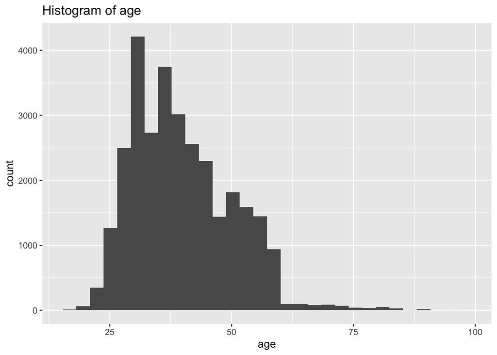

```r
bankTrain %>%
  ggplot(aes(age)) + geom_histogram() +
  labs(title = "Histogram of age")
```

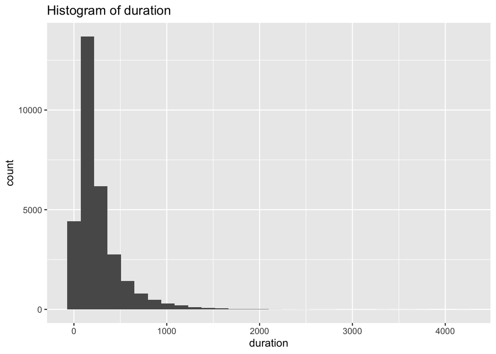

```r
bankTrain %>%
  ggplot(aes(duration)) + geom_histogram() +
  labs(title = "Histogram of duration")
```

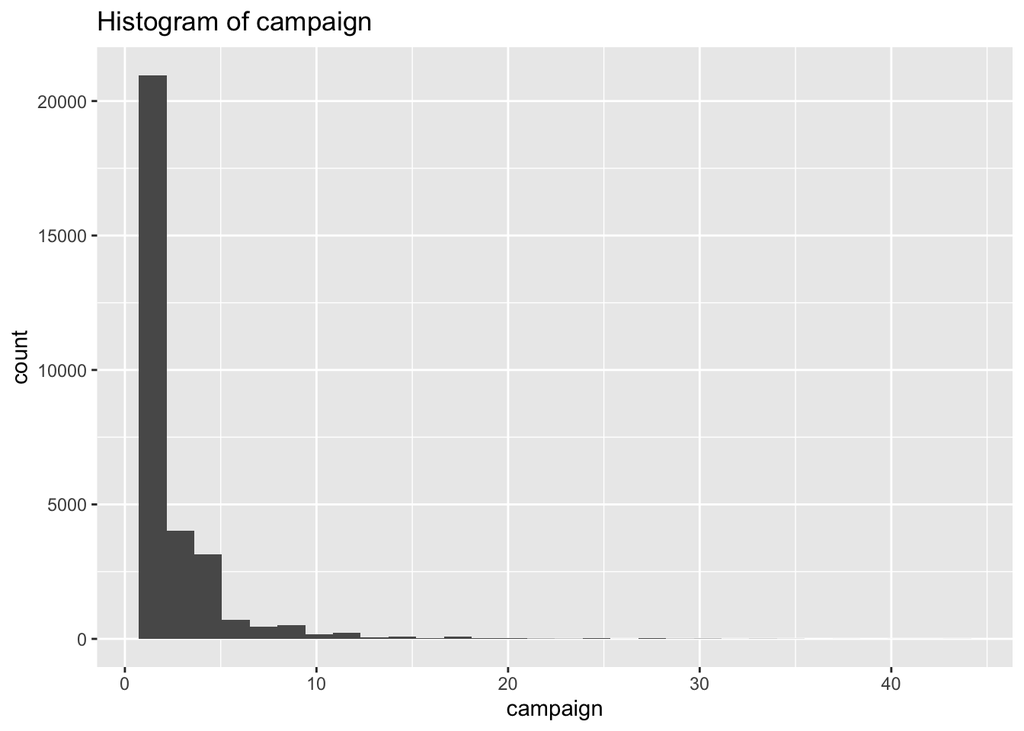

```r
bankTrain %>%
  ggplot(aes(campaign)) + geom_histogram() +
  labs(title = "Histogram of campaign")
```

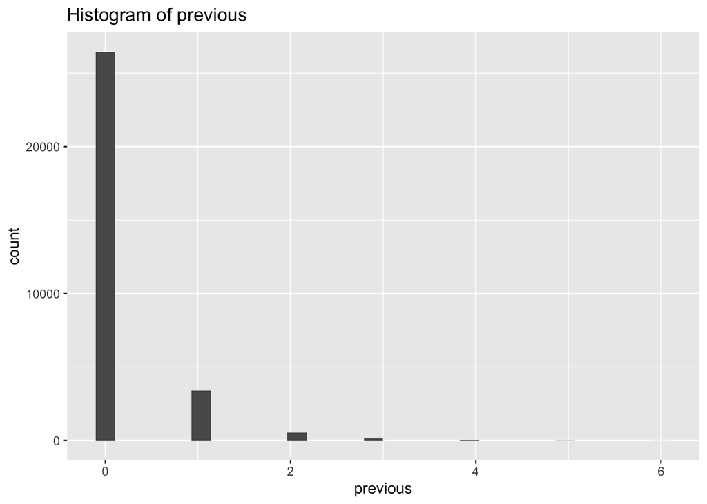

```r
bankTrain %>%
  ggplot(aes(previous)) + geom_histogram() +
  labs(title = "Histogram of previous")
```

```r
table(bankTrain$previous)
```

```
##
##     0     1     2     3     4     5     6
## 26451  3386   531   164    50    11     3
```

We will use log transformation on `duration` and `campaign`. We will also turn `previous` into a categorical variable.

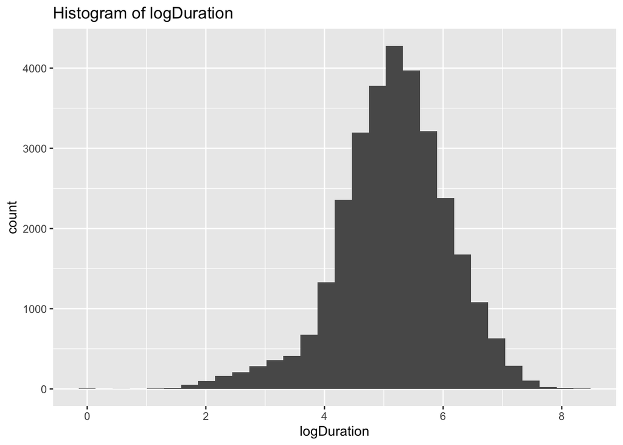

```r
#log transformation
bankTrain <- bankTrain %>%
  mutate(logDuration = log(duration))

bankTrain <- bankTrain %>%
  mutate(logCampaign = log(campaign))

bankTrain %>%
  ggplot(aes(logDuration)) + geom_histogram() +
  labs(title = "Histogram of logDuration")
```